# EDA with R.2

Antonio Henrique

01/07/2021

# 1. Análise exploratória de dados

Para solução de problemas orientados a dados, necessitamos conhecer bem a estrutura e as características das informações com as quais estamos trabalhando. Ao formular um problema de pesquisa que será respondido através da realização de experimentos, devemos saber de antemão quais variáveis serão observadas e valores devemos esperar de cada uma.

Com o intuito de compreender melhor os dados que utilizamos na construção de um programa, dispomos de técnicas de visualização que nos permitem identificar as principais características, além de possíveis correlações e discrepâncias das amostras coletadas.

Essas técnicas vem sendo desenvolvidas há séculos como ferramentas auxiliares na realização de cálculos estatísticos, e o principal objetivo é evidenciar certas características de interesse do fenômeno que estamos observado. Essas características incluem, por exemplo, as medidas de localização e de dispersão da amostra.

Essas medidas são descritas na forma de **estatísticas** (uma função dos valores coletados da amostra), e essas estatísticas são utilizadas para analisar e modelar o comportamento do processo que gerou a amostra.

Em geral modelamos as características de nossos objetos de estudo na forma de **variáveis aleatórias**, e estas variáveis aleatórias assumem valores numéricos, sejam eles contínuos ou discretos.

- Variáveis aleatórias contínuas podem assumir qualquer valor real. Este tipo de informação em geral é proveniente da medição de alguma quantidade física. Podemos citar por exemplo a altura dos participantes da turma.
- Variáveis aleatórias discretas assumem apenas um conjunto conhecido de números. Existem duas situações em que este tipo de variável estará presente:
  - Variáveis de contagem, como por exemplo o número de participantes desta turma. Neste caso o conjunto de possíveis valores é o conjunto dos números naturais (*integer*).
  - Variáveis categóricas, como por exemplo o sexo de cada participante desta turma. Neste caso o conjunto de possíveis valores é um conjunto finito de valores (*factor*).

# 2. Modelagem Estatística

Para uma melhor visualização dos dados necessitamos de um conjunto de princípios teóricos que orientem a gramática que será utilizada na leitura dos gráficos produzidos. Aqui trabalharemos com as técnicas da modelagem estatística, portanto é necessário entender que um dos objetivos dessas técnicas é analisar e interpretar um fenômeno aleatório, de forma que a **perda de informação** proveniente da análise seja controlada.

Dizemos que há perda de informação quando reduzimos a complexidade do objeto de estudo a um conjunto numérico de valores. Dessa forma é inerente à experimentação cientifíca uma perda de informação relacionada ao processo de amostragem, isto é, os dados coletados não contém toda a informação necessária para compreender completamente o fenômeno em estudo.

Além disso, quando resumimos a informação de uma amostra por alguma função dos valores amostrais, como a média ou o mínimo, há uma segunda perda de informação. Para facilitar este processo de modelagem trabalhamos com funções já conhecidas e com boas propriedades, geralmente chamadas de medidas de localização e de dispersão.

## 2.1. Medidas de localização

Medidas de localização são estatísticas que nos informam em qual região do conjunto de possíveis valores se concentram nossas variáveis. Por exemplo, o valor mínimo, o valor máximo, a média e a mediana. Estas estatísticas nos dão uma ideia dos limites de valores que nossas variáveis assumem, além dos valores mais prováveis de serem observados.

Seja $x_1, x_2, x_3, ..., x_n$ uma amostra aleatória da variável contínua $X$. Vejamos abaixo a definição dessas estatísticas:

### 2.1.1. Mínimo e Máximo

O valor mínimo e o valor máximo de uma variável representam os limites dos valores que essa variável pode assumir. Em dados de contagem, por exemplo, sabemos que o valor mínimo é 0 e o valor máximo é $+ \infty$, todavia em muitas situações os limites teóricos são muito abrangentes e portanto é interessante ser capaz de estimá-lo.

$$min(X) = X_{(1)} = min(x_1, x_2, ..., x_n)$$
$$max(X) = X_{(n)} = max(x_1, x_2, ..., x_n)$$

### 2.1.2. Média

A média de uma amostra aleatória é uma função de extrema importância para modelagem estatística, uma vez que o valor médio muitas vezes é uma informação que resume bem a característica de interesse. De forma conceitual, o valor médio é obtido de forma que possamos substituir os dados amostrais por ele, sem que haja grande perda de informação.

$$\bar x = \sum_{i=1}^n { {x_i} \over {n} }$$

### 2.1.3. Mediana

Além de determinar um valor de referência para nossa amostra, como a média, em geral é útil determinar também se é mais provável encontrar valores maiores ou menores do que essa referência. Para isto existem medidas denominadas **quantis** e um deles é a mediana.

Seja $X_{(1)} = min(X)$ o menor valor da amostra, $X_{(2)}$ o segundo menor valor, $X_{(3)}$ o terceiro menor valor e assim por diante, até $X_{(n)}$ o maior valor da amostra. A mediana é definida como $X_{({{n+1} \over {2}})}$, caso n seja ímpar, e ${X_{({{n} \over {2}})} + X_{({{n} \over {2} }+1)}} \over {2}$ caso n seja par.

De forma conceitual a mediana divide a amostra em dois grupos de mesma probabilidade, metade da amostra será maior do que a mediana e a outra metade da amostra será menor. Portanto, se em uma amostra a mediana é maior do que a média, temos um indício de que os valores da variável se concentram acima da média. Caso a mediana seja menor do que a média, o contrário ocorre.

É possível definir quantis como a mediana para qualquer valor de probabilidade entre 0 e 1. Por exemplo, suponha que queiramos definir o quantil de 25%, definido como $q_{0.25}$. Este é o valor que divide o espaço amostral de $X$ em duas partes, sendo que a chance de observarmos valores de $X$ menores do que $q_{0.25}$ é de 25%, enquanto a chance de observar valores de $X$ maiores do que $q_{0.25}$ é de 75%. Os quantis de 25% e 75% são chamados de primeiro e terceiro quartis respectivamente. Estes valores, em conjunto com a mediana nos fornecem informações sobre a assimetria de nossas variáveis.

## 2.2. Medidas de dispersão

Chamamos de dispersão de uma variável aleatória a magnitude da discrepância que esperamos observar entre os valores que compôem o intervalo amostral. Em outras palavras, uma medida de dispersão é um valor numérico que representa o quão distante os valores observados estão uns dos outros. Conforme aumenta a diferença entre os elementos de uma amostra, também aumenta a dispersão.

Trabalharemos com três medidas de dispersão neste curso, a variância, o desvio padrão e a distância interquartílica.

### 2.2.1. Variância

A variância de uma amostra é definida como:

$$Var(X) = s^2_x = \sum_{i=1}^n { {(x_i - \bar x)^2} \over {n} }$$

A quantidade $x_i - \bar x$ é chamada de desvio amostral do indivíduo $i$ em relação a média $\bar x$. Note que a soma dos desvios amostrais para uma amostra é sempre igual a 0:

$$\sum_{i=1}^n (x_i - \bar x) = \sum_{i=1}^n x_i - \sum_{i=1}^n \bar x \\
= \sum_{i=1}^n x_i - n \cdot \bar x \\
= \sum_{i=1}^n x_i - n \cdot \sum_{i=1}^n {{x_i} \over {n}} \\
= \sum_{i=1}^n x_i - \sum_{i=1}^n {x_i} \\
= 0$$

Dessa forma não é possível ter ideia do desvio total da amostra em relação a média apenas somando os desvios de cada indivíduo. Essa ideia de desvio total é que chamamos de dispersão. Para que seja possível definir uma estatística baseada nos desvios individuais devemos primeiro elevá-los ao quadrado. Outra alternativa seria utilizar o valor absoluto do desvio.

### 2.2.2. Desvio padrão

Observe que a variância é definida como a média dos desvios quadráticos, desta forma ela está em uma escala diferente da variável observada. Suponha um experimento onde precimos medir o comprimento de algumas folhas de uma determinada espécie de planta. Cada medida será registrada na escala de centímetros ($cm$). Todavia o desvio quadrático médio estará na escala de centímetros quadrados ($cm^2$).

Uma estatística que representa o desvio ao qual estamos sujeitos, utilizando a média como resumo dos dados, é o desvio padrão obtido pela raiz quadrada da variância. Isto é,

$$s_x = \sqrt[ ]{s_x^2} = \sqrt[ ]{ \sum_{i=1}^n { {(x_i - \bar x)^2} \over {n} } }$$

### 2.2.3. Distância Interquartílica

Uma outra forma de representar a dispersão dos dados e que leva em consideração a assimetria dos dados é a distância interquartílica, definida como a diferença entre o terceiro e o primeiro quartil amostral. Isto é

$$d_{(0.75, 0.25)} = q_{0.75} - q_{0.25}$$

Onde $q_{0.75}$ e $q_{0.25}$ são os quantis de probabilidade $0.75$ e $0.25$, respectivamente.

# 3. Interpretação das estatísticas

Focaremos nossos estudos na média, na mediana, no desvio padrão e na distância interquartílica. As duas primeiras medidas são de localização e nos informam em torno de qual valor a nossa amostra se concentra. As duas últimas são medidas de dispersão e nos auxiliam na tarefa de estabelecer os limites de confiança que serão utilizados na análise dos dados.

De forma geral supomos que as características que estamos analisando se comportam de forma controlada em torno de um valor médio, e supomos também que e a variação em torno da média é limitada. Dessa forma conhecer a média e a variância de uma variável é suficiente para obter uma ideia geral de seu comportamento.

Para verificar a presença de supostas irregularidades nessas condições dispomos da mediana e da distância interquartílica, que juntas fornecem informação mais realista para estimar o intervalo de confiança da amostra.

Considere por exemplo os seguintes dados provenientes da área de nutrição e registram o comprimento de células de odontoblasto em uma amostra de 60 porquinhos-da-índia após a aplicação de uma dieta de vitamina C. Estes dados estão disponíveis de forma pública no ambiente R e são utilizados para fins didáticos e como documentação da própria linguagem.

Os dados são compostos de 60 observações, uma para cada porquinho-da-índia, e registram as seguintes variáveis:

- *dose*: Dose diária administrada para o indivíduo durante a dieta, podendo ser **0.5**, **1.0** ou **2.0**;
- *supp*: Forma de administração utilizada, podendo ser **OJ - suco de laranja** ou **VC - ácido ascórbico** ;
- *len*: Comprimento da célula para aquele indivíduo, sendo um número real.

```r
# Importação dos dados
data("ToothGrowth")

# Interrogação é para ver a documentação
?ToothGrowth
```

```
## starting httpd help server ... done
```

```r
?list

print(ToothGrowth)
```

```
##     len supp dose
## 1   4.2   VC  0.5
## 2  11.5   VC  0.5
## 3   7.3   VC  0.5
## 4   5.8   VC  0.5
## 5   6.4   VC  0.5
## 6  10.0   VC  0.5
## 7  11.2   VC  0.5
## 8  11.2   VC  0.5
## 9   5.2   VC  0.5
## 10  7.0   VC  0.5
## 11 16.5   VC  1.0
## 12 16.5   VC  1.0
## 13 15.2   VC  1.0
## 14 17.3   VC  1.0
```

[output cut: 46 more lines]

```r
# Experimente: View(ToothGrowth)
```

Num primeiro momento vamos observar apenas a variável *len* (comprimento da célula). O código abaixo extrai essa variável do **data.frame** original e define alguns objetos contendo as estimativas das quatro estatísticas de estudo para a variável *len*:

```r
# Salvo os dados do peso no objeto MassaVegetal
Comprimento = ToothGrowth$len

media = mean(Comprimento)
desvio_padrao = sd(Comprimento)
# Alternativamente, desvio_padrao = sqrt(var(Comprimento))


mediana = quantile(Comprimento, 0.5)
terceiro.quartil = quantile(Comprimento, 0.75)
primeiro.quartil = quantile(Comprimento, 0.25)
distancia_interquatilica = terceiro.quartil - primeiro.quartil

print(paste('Média:', media, '; Desvio Padrão:', desvio_padrao))
```

```
## [1] "Média: 18.8133333333333 ; Desvio Padrão: 7.64931517188761"
```

```r
print(paste('Mediana:', mediana, '; Distância interquartílica:', distancia_interquatilica))
```

```
## [1] "Mediana: 19.25 ; Distância interquartílica: 12.2"
```

Nosso primeiro objetivo é determinar a região onde os valores da variável se concentram. Para isto utilizaremos de dois métodos.

# 4. Intervalo de confiança a partir da média e da variância

Neste primeiro método assumimos que a faixa onde nossos dados se concentram está localizada em torno da média e seu comprimento é dado por um múltiplo do desvio padrão.

Para os dados utilizados, podemos construir uma região centrada na média e cujos os limites estão localizados a uma distância de 1 desvio padrão do centro.

```r
intervalo.1.minimo = media - 1 * desvio_padrao
intervalo.1.maximo = media + 1 * desvio_padrao

intervalo.1 = c(intervalo.1.minimo, intervalo.1.maximo)
names(intervalo.1) = c('minimo', 'maximo')

print(intervalo.1)
```

```
##   minimo   maximo
## 11.16402 26.46265
```

Verifiquemos essa informação visualmente:

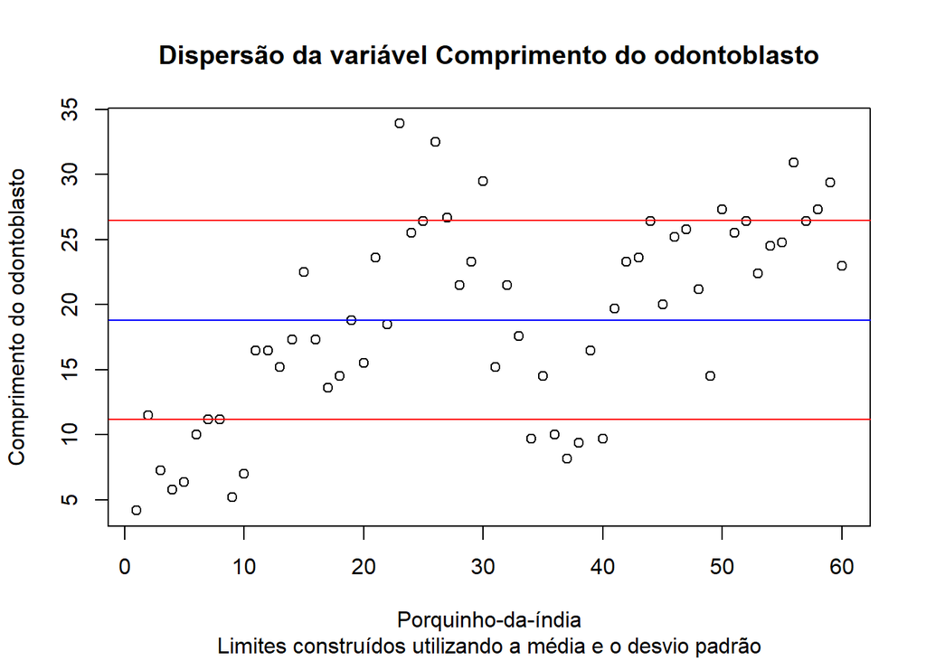

```r
plot(Comprimento,
     xlab = 'Porquinho-da-índia',
     ylab = 'Comprimento do odontoblasto')
abline(h = media, col = 'blue')
abline(h = intervalo.1['minimo'], col = 'red')
abline(h = intervalo.1['maximo'], col = 'red')

title(main = 'Dispersão da variável Comprimento do odontoblasto',
      sub = 'Limites construídos utilizando a média e o desvio padrão')
```

Observe como os dados se distribuem ao redor da média. As linhas vermelhas delimitam o nosso intervalo de confiança esperado e a azul representa a média da amostra. Note ainda que a maioria dos indivíduos está à uma distância menor do que um desvio padrão da média.

Confira a seguir a proporção de indivíduos que se encontram fora do intervalo de confiança adotado:

```r
quantidade_total = length(Comprimento)

abaixo_limite_inferior = Comprimento < intervalo.1['minimo']
acima_limite_superior = Comprimento > intervalo.1['maximo']

quantidade_fora = sum(abaixo_limite_inferior | acima_limite_superior)

proporcao = quantidade_fora / quantidade_total

print(proporcao)
```

```
## [1] 0.3333333
```

A proporção encontrada foi de $0.333$, isto é, um terço dos indivíduos da amostra estão a uma distância maior do que um desvio padrão da média.

# 5. Intervalo amostral a partir dos quantis

Uma forma alternativa de construir esse intervalo sem supor que os dados se distribuem de forma simétrica ao redor da média é utilizando os quantis amostrais. Neste caso o limite inferior de confiança é dado pelo primeiro quartil amostral subtraído por um fator da distância interquartílica, e o limite superior de confiança é dado pelo terceiro quartil amostral somado deste mesmo fator.

Observe abaixo a construção do intervalo de confiança utilizando um fator de meia distância interquartílica:

```r
intervalo.2.minimo = primeiro.quartil - 0.5 * distancia_interquatilica
intervalo.2.maximo = terceiro.quartil + 0.5 * distancia_interquatilica

intervalo.2 = c(intervalo.2.minimo, intervalo.2.maximo)
names(intervalo.2) = c('minimo', 'maximo')

print(intervalo.2)
```

```
## minimo maximo
##  6.975 31.375
```

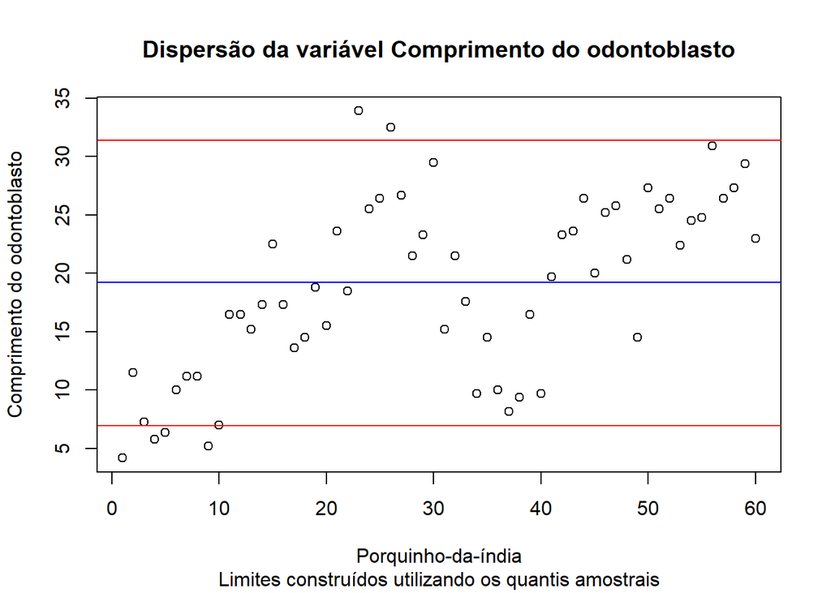

```r
plot(Comprimento,
     xlab = 'Porquinho-da-índia',
     ylab = 'Comprimento do odontoblasto')
abline(h = mediana, col = 'blue')
abline(h = intervalo.2['minimo'], col = 'red')
abline(h = intervalo.2['maximo'], col = 'red')

title(main = 'Dispersão da variável Comprimento do odontoblasto',
      sub = 'Limites construídos utilizando os quantis amostrais')
```

# 6. Plots básicos

Utilizando a linguagem R temos disponíveis algumas ferramentas padrão para criar imagens. Estas ferramentas estão localizadas nas bibliotecas *base* e *graphics*, ambas dísponíveis no contexto padrão do ambiente.

Para ver a documentação da biblioteca *graphics*, execute os seguintes comandos:

```r
?graphics
library(help = 'graphics')
```

## 6.1. Boxplot

A primeira análise a ser realizada com os dados de um experimento é a estimação do intervalo onde os valores de sua amostra se localizam. Um diagrama muito útil para exibir essa informação é o **boxplot**, proposto pelo estatístico John Tukey. Neste diagrama observamos ao mesmo tempo os quartis, um intervalo de confiança e pontos discrepantes da amostra.

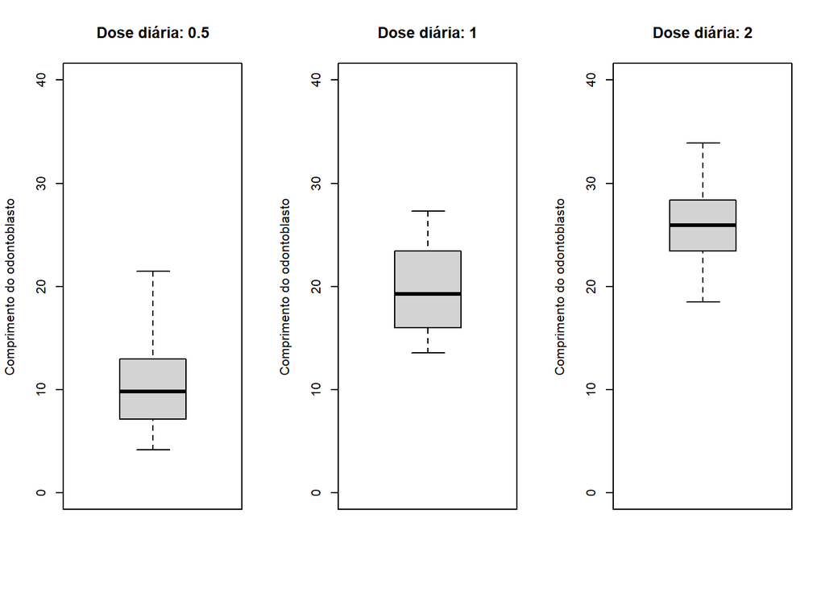

```r
niveis.dose = unique(ToothGrowth$dose)

par(mfrow = c(1, length(niveis.dose)))

for(nivel.dose in niveis.dose) {
   df.dose = subset(ToothGrowth, dose == nivel.dose)

   boxplot(df.dose$len,
           main = paste('Dose diária:', nivel.dose),
           ylim = c(0, 40),
           xlab = '',
           ylab = 'Comprimento do odontoblasto')
}
```

Neste diagrama podemos ver que o comprimento do odontoblasto varia de cerca de 5 até 35. Além disso a mediana de cada grupo é consideravelmente diferente dos outros. Podemos notar também que o segundo grupo, ao qual foi administrada a dose diária de 1 mg, a distância interquartílica é ligeiramente maior do que nos outros dois grupos.

## 6.2. Scatter Plot ou Diagrama de Dispersão

O gráfico que representa a variação conjunta de duas variáveis numéricas é chamado de *diagrama de dispersão*. Através dele somos capazes de identificar possíveis **associações** entre as variáveis em estudo. Para ilustrar o processo de construção considere as variáveis *dose* e *len* dos dados importados:

```r
ToothGrowth[, c('dose', 'len')]
```

```
##    dose  len
## 1   0.5  4.2
## 2   0.5 11.5
## 3   0.5  7.3
## 4   0.5  5.8
## 5   0.5  6.4
## 6   0.5 10.0
## 7   0.5 11.2
## 8   0.5 11.2
## 9   0.5  5.2
## 10  0.5  7.0
## 11  1.0 16.5
## 12  1.0 16.5
## 13  1.0 15.2
## 14  1.0 17.3
```

[output cut: 46 more lines]

Para representar graficamente a maneira como a variável *len* se comporta em relação à alterações na variável *dose* dispomos estas variáveis em dois eixos coordenados. A **variável resposta** é disposta no eixo vertical enquanto a **variável explicativa** é disposta no eixo horizontal.

Em seguida, para cada par de observações da amostra, adicionamos um ponto nas respectivas coordenadas dos eixos construídos anteriormente.

Este procedimento é implementado na função **plot** do pacote *base*:

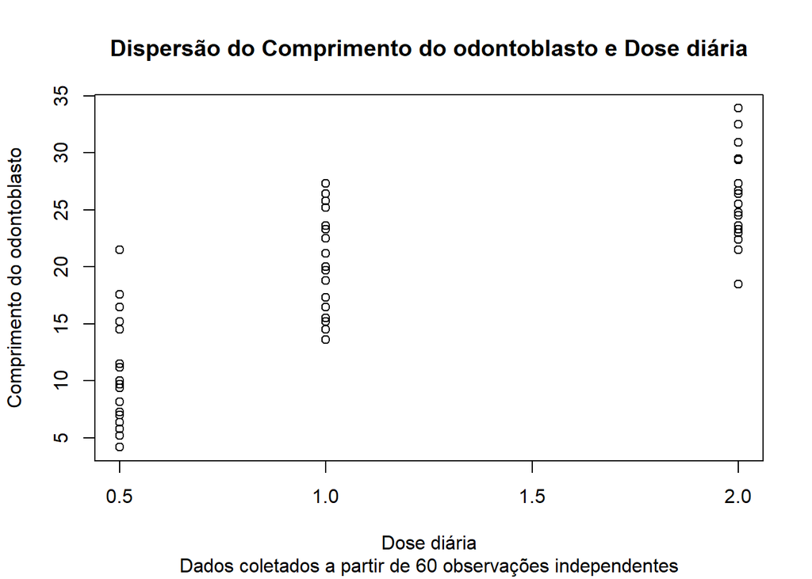

```r
?base::plot

plot(x = ToothGrowth$dose, y = ToothGrowth$len,
     main = 'Dispersão do Comprimento do odontoblasto e Dose diária',
     sub = 'Dados coletados a partir de 60 observações independentes',
     xlab = 'Dose diária',
     ylab = 'Comprimento do odontoblasto')
```

Observe que há sobreposição de vários indivíduos na variável *dose*, isto ocorre porque a dose administrada aos indivíduos é um fator de tratamento do experimento, isto é, vários indivíduos foram observados sob as mesmas condições de controle para esta variável.

## 6.3. Gráfico de barras

Para fins de ilustração, vamos apresentar também os valores médios de cada grupo em um gráfico de barras.

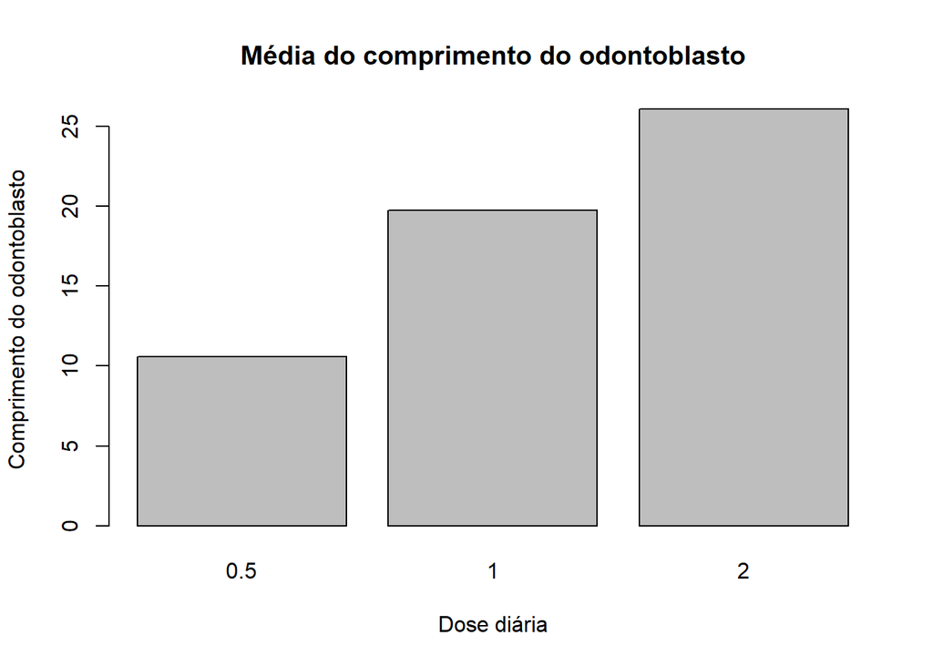

```r
obter_media_grupo = function (nivel.dose) {

   df.dose = subset(ToothGrowth, dose == nivel.dose)

   return(mean(df.dose$len))

}

medias_tratamentos = sapply(niveis.dose, obter_media_grupo)
names(medias_tratamentos) = niveis.dose

barplot(medias_tratamentos,
        main = 'Média do comprimento do odontoblasto',
        xlab = 'Dose diária',
        ylab = 'Comprimento do odontoblasto')
```

# 7. Exercícios

1. Crie os boxplots do comprimento do odontoblasto para os dados *ToothGrowth*, mas agora considere como variável explicativa a forma de administração utilizada (*sup*). Qual a interpretação do gráfico?
2. Importe os dados presentes na biblioteca **chickwts**. Isto pode ser feito executando o comando *data(‘chickwts’)*. Ao fazer isto o objeto **ChickWeight**, do tipo *data.frame*, estará presente na memória.

   2.1. Crie o data.frame **galinha1** a partir das linhas de **ChickWeight** onde a coluna *Chick* seja igual a 1. Selecione apenas as colunas *weight* e *Time*.

   2.2. Considerando que a variável explicativa é *Time* e a variável resposta é *weight*, faça o diagrama de boxplot para a variável resposta e faça também o diagrama de dispersão conjunta da variável resposta em relação a variável explicativa.

   2.3. Considerando agora que a variável explicativa é a *Diet*, obtenha o valor médio dos pesos das galinhas para cada nível de tratamento. Faça o gráfico de barras do peso médio em cada dieta.